# 20220317回家作業

分析 初始資金/玩得次數/勝率的關係

```r
##摩天大樓下注法
##無論輸贏皆下注一次
calc_skyscrape_bet <- function(){
  return(bet=1)
}

##馬丁格爾下注法
##贏了下注一倍，輸了翻倍下
calc_martingale_bet <- function(outcome,bet){
  if(outcome==1) return(bet=1)
  else return(bet*2)
}

##費波那契下注法
##贏了下注一倍，輸了按費波那契數列Fibonacci, Fn的規則的比例下注（1,1,2,3,5,8,13,21,...）
clac_fibonacci_bet <- function(outcome,bet,f_bet){
  if(outcome==1) return(bet = 1)
  else return(sum(tail(f_bet,2)))
}
```

```r
##get_record()函式，計算x次實驗最後籌碼數
##參數：init初始籌碼，test_count實驗次數，leave_count離場次數，probability輸贏機率
##      record紀錄實驗籌碼數，betting_method（摩天大樓：1，馬丁格爾：2，費波那契：3）
##返回值：用某個下注法，實驗X次，在某個機率下，籌碼不夠及離場次數到時，返回實驗的結果

get_record <- function(init,test_count,leave_count,probability,record,betting_method){

  for (i in 1:test_count) { #實驗次數

    coin = init     ##目前籌碼
    bet = 1         ##當前下注數
    f_bet = c(0, 1) ##費波那契下注數初始值

    while (bet < tail(coin, 1) && length(coin) < leave_count) {         ##籌碼不足且離場次數未到

      outcome = sample(c(-1, 1), 1, prob = probability, replace = TRUE) ##根據給定計算輸贏結果

      coin = c(coin, tail(coin, 1) + bet * outcome)           ##根據輸贏及下注結果，計算這次籌碼數量，並加進籌碼紀錄

      result <- switch(       ##選擇下注法並計算下注數
        betting_method,
        calc_skyscrape_bet(),
        calc_martingale_bet(outcome, bet),
        clac_fibonacci_bet(outcome, bet, tail(f_bet, 2))
      )

      bet = result       ##更新下注數

      if (outcome == 1) f_bet <- c(0, 1) ##若用費波那契法，若贏，費波那契初始值重置
      else f_bet <- c(f_bet, result)     ##若用費波那契法，若輸，更新投注數

    }
    record = c(record, tail(coin, 1))    ##紀錄當前實驗最後的籌碼數
  }
  return(record) ##返回總實驗次數的最後籌碼數
}
```

```r
#plot_result()函式，繪製結果
#參數：init初始籌碼，test_count實驗次數，leave_count離場次數，prob輸贏機率
#      record紀錄實驗籌碼數，over_chips超過多少籌碼值
#返回值：給定實驗次數，繪製三種方法的直方圖，及相關資訊


plot_result <-function(init,testcount,leave_count,prob,record,over_chips) {

    for (i in 1:length(testcount)) { ##重複實驗次數次

      ##這個判斷用於計算機率百分比
      if (testcount[i] < 1000)
        x = 1
      else if (testcount[i] < 10000)
        x = 10
      else if (testcount[i] >= 10000)
        x = 100

      test_count = testcount[i] ##傳進實驗次數的值

      ##繪製摩天大樓下注法結果
      sbm_record <-get_record(init, test_count, leave_count, prob, record, 1)
      hist(
        sbm_record,##實驗結果
        xlab = "Record (skyscrape)", ##x軸的文字
        ylab = "Grand total",        ##y軸的文字
        col = "red",                 ##直方圖顏色
        label = TRUE,                ##繪製直方圖的數值
        cex.main = 0.8,              ##縮小主標題文字大小
        main = paste(                ##主標題繪製文字，繪製初始值，離場次數，實驗次數，贏的機率，超過多少枚籌碼的機率
          init,
          "Chips,Play <= ",
          leave_count,
          "Times,Test",
          test_count,
          "times;\nProb of win",
          length(sbm_record[sbm_record > init]) / x,
          "%,\nProb of The last over",
          over_chips,
          "chips prob ",
          length(sbm_record[sbm_record >= over_chips]) / x,
          "%,"
        )
      )

      ##繪製馬丁格爾下注法結果
      mbm_record <- get_record(init, test_count, leave_count, prob, record, 2)
      hist(
        mbm_record,
        xlab = "Record (martingale)",
        ylab = "Grand total",
        col = "pink",
        label = TRUE,
        cex.main = 0.8,
        main = paste(
          init,
          "Chips,Play <= ",
          leave_count,
          "Times,Test ",
          test_count,
          "times;\nProb of win ",
          length(mbm_record[mbm_record > init]) / x,
          "%,\nProb of The last over",
          over_chips,
          "chips ",
          length(mbm_record[mbm_record >= over_chips]) / x,
          "%,"
        )
      )

      ##繪製費波那契下注法結果
      fbm_record <- get_record(init, test_count, leave_count, prob, record, 3)
      hist(
        fbm_record,
        xlab = "Record (fibonacci)",
        ylab = "Grand total",
        col = "green",
        label = TRUE,
        cex.main = 0.8,
        main = paste(
          init,
          "Chips,Play <= ",
          leave_count,
          "Times,Test ",
          test_count,
          "times;\nProb of win ",
          length(fbm_record[fbm_record > init]) / x,
          "% \nProb of The last over",
          over_chips,
          "chips ",
          length(fbm_record[fbm_record >= over_chips]) / x,
          "%,"
        )
      )
    }
  }
```

# 分析不同初始資金與勝率及回報率之間的關係

## **有錢愛玩型：**

初始籌碼100，實驗三次（分別為100次，1000次，10000次），機率輸19/37，贏18/37，離場次數80，超過120枚籌碼。

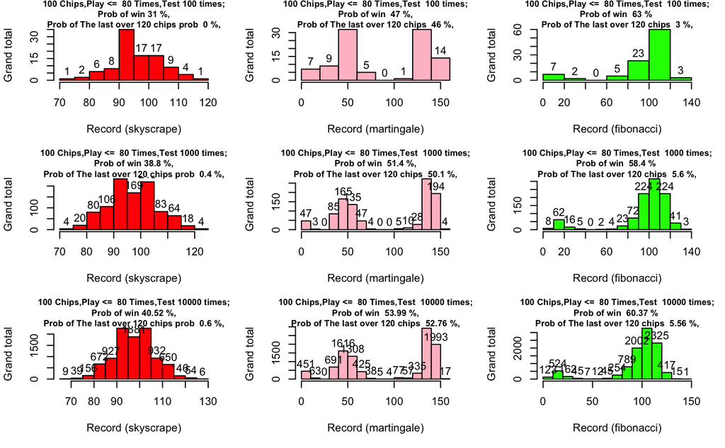

```r
init = 100 ##初始籌碼
test_count = c(100,1000,10000) ##實驗次數分別為 100次，1000次，10000次
prob = c(19/37,18/37)          ##機率（輸，贏）
record=NULL                    ##初始紀錄籌碼數結果
leave_count=80                 ##離場次數（多少次就要離場）
over_chips=120                 ##超過多少枚籌碼

##運行式解除注釋，否則輸出html時會重新run
par(mfrow = c(length(test_count),3))  ##多圖合一，（列，行），由實驗次數（幾次實驗）決定繪製幾行
plot_result(init,test_count,leave_count,prob,record,over_chips) ##繪製結果
```

| Betting Method | Prob(Win) 100times | Prob(Win) 1000times | Prob(Win) 10000times | Prob 100times (Over12OChips） | Prob 1000times (Over12OChips) | Prob10000times (Over12OChips) |
| --- | --- | --- | --- | --- | --- | --- |
| Skyscrape | 31% | 38.8% | 40.52% | 0% | 0.4% | 0.6% |
| Martingale | 47% | 51.4% | 53.99% | **46%** | **50.1%** | **52.76%** |
| Fibonacci | **63%** | **58.4%** | **60.37%** | 3% | 5.6% | 5.56% |

實驗結果表面，**當初始籌碼為100時**，摩天大樓型勝率最低，費波那契勝率最高，但是馬丁格爾緊接費波其後。而初始籌碼100情況下，最後超過120枚籌碼，馬丁格爾勝率均超過40%以上，而其他兩種方法均未超過10%，摩天大樓法效果最差。從圖像上分析，馬丁格爾出現了雙峰的型態，比較極端。而費波那契則較為緩和。

策略：

| Betting Method | 穩健養老型 | 飛黃騰達型 | 輸到賠褲型 |
| --- | --- | --- | --- |
| Skyscrape | x | x | √ |
| Martingale | x | √ | x |
| Fibonacci | √ | x | x |

# **沒錢硬要型：**

初始籌碼10，實驗三次（分別為100次，1000次，10000次），機率輸19/37，贏18/37，離場次數80，超過20枚籌碼。

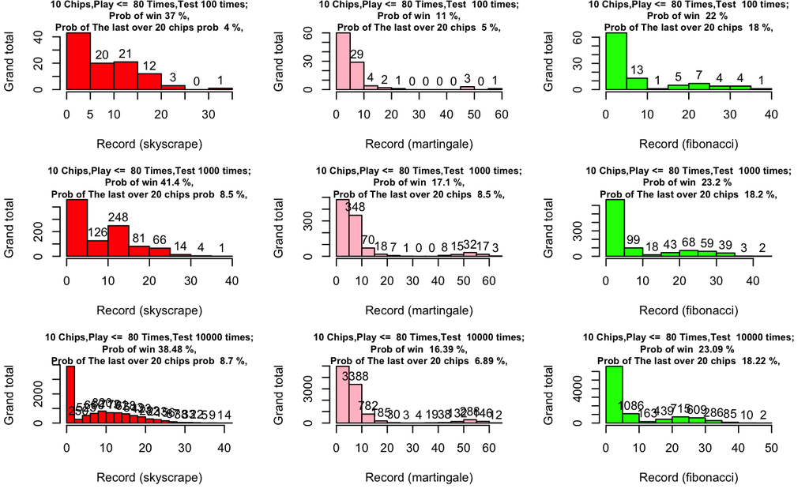

```r
init = 10 ##初始籌碼
test_count = c(100,1000,10000) ##實驗次數分別為 100次，1000次，10000次
prob = c(19/37,18/37)          ##機率（輸，贏）
record=NULL                    ##初始紀錄籌碼數結果
leave_count=80                 ##離場次數（多少次就要離場）
over_chips=20                ##超過多少枚籌碼

##運行時解除注釋，因為輸出html時會重新run
par(mfrow = c(length(test_count),3))  ##多圖合一，（列，行），由實驗次數（幾次實驗）決定繪製幾行
plot_result(init,test_count,leave_count,prob,record,over_chips) ##繪製結果
```

| Betting Method | Prob(Win) 100times | Prob(Win) 1000times | Prob(Win) 10000times | Prob 100times (Over2OChips） | Prob 1000times (Over2OChips) | Prob10000times (Over2OChips) |
| --- | --- | --- | --- | --- | --- | --- |
| Skyscrape | **37%** | **41.4%** | **38.48%** | 4% | 8.5% | 8.7% |
| Martingale | 11% | 17.1% | 16.39% | 5% | 8.5% | 6.89% |
| Fibonacci | 22% | 23.2% | 23.09% | **18%** | **18.2%** | **18.22%** |

策略：

| Betting Method | 穩健養老型 | 飛黃騰達型 | 輸到賠褲型 |
| --- | --- | --- | --- |
| Skyscrape | √ | x | x |
| Martingale | x | x | √ |
| Fibonacci | x | √ | x |

# 總結：

沒錢不要賭，十賭九輸。

從模擬的角度而言，老師課上所言「沒錢就老實投資理財存錢」甚有道理。

初始值低時，摩天大樓穩健的下注法，會大大提高勝率，風險隨之降低；

而有錢時，可以採取相對大膽的策略，因為贏的機率大幅提高，而保守的策略反而損失更大。

Anyway,`選擇（投胎 maybe ）比努力更重要。`